# 1-data-preprocess

Find the union set of selected features across all data files

```python
selected_features_common = []
for dataset_file, features_list in sorted(selected_features.items()):
  print(f'Merging features for {dataset_file}', features_list)
  for feature in features_list:
    if feature not in selected_features_common:
      selected_features_common.append(feature)
```

```
Merging features for cse-cic-ids2018/Friday-02-03-2018_TrafficForML_CICFlowMeter.csv ['Flow Byts/s', 'Flow Pkts/s', 'Flow Duration']
Merging features for cse-cic-ids2018/Friday-16-02-2018_TrafficForML_CICFlowMeter.csv ['Fwd Pkt Len Std', 'Bwd IAT Min', 'PSH Flag Cnt']
Merging features for cse-cic-ids2018/Friday-23-02-2018_TrafficForML_CICFlowMeter.csv ['RST Flag Cnt', 'Bwd Pkt Len Max', 'Pkt Len Std']
Merging features for cse-cic-ids2018/Thuesday-20-02-2018_TrafficForML_CICFlowMeter.csv ['TotLen Fwd Pkts']
Merging features for cse-cic-ids2018/Thursday-01-03-2018_TrafficForML_CICFlowMeter.csv ['Fwd Seg Size Min', 'Init Fwd Win Byts', 'Pkt Len Max', 'Bwd Header Len', 'Init Bwd Win Byts', 'ECE Flag Cnt']
Merging features for cse-cic-ids2018/Thursday-15-02-2018_TrafficForML_CICFlowMeter.csv ['Fwd Seg Size Min', 'Init Fwd Win Byts', 'Bwd Header Len', 'TotLen Bwd Pkts']
Merging features for cse-cic-ids2018/Thursday-22-02-2018_TrafficForML_CICFlowMeter.csv ['Bwd Pkt Len Max', 'Pkt Len Max', 'TotLen Fwd Pkts', 'Flow Byts/s']
Merging features for cse-cic-ids2018/Wednesday-14-02-2018_TrafficForML_CICFlowMeter.csv ['Fwd Seg Size Min', 'Flow Pkts/s']
Merging features for cse-cic-ids2018/Wednesday-21-02-2018_TrafficForML_CICFlowMeter.csv ['Bwd Pkt Len Std']
Merging features for cse-cic-ids2018/Wednesday-28-02-2018_TrafficForML_CICFlowMeter.csv ['Flow IAT Max']
```

```python
print(f'Number of selected features {len(selected_features_common)}')
for feature in selected_features_common:
  print(feature)
```

```
Number of selected features 19
Flow Byts/s
Flow Pkts/s
Flow Duration
Fwd Pkt Len Std
Bwd IAT Min
PSH Flag Cnt
RST Flag Cnt
Bwd Pkt Len Max
Pkt Len Std
TotLen Fwd Pkts
Fwd Seg Size Min
Init Fwd Win Byts
Pkt Len Max
Bwd Header Len
Init Bwd Win Byts
ECE Flag Cnt
TotLen Bwd Pkts
Bwd Pkt Len Std
Flow IAT Max
```

Save selected features data into new csv files

```python
dataset_name_clean = dataset_name + '-clean'
```

```python
!mkdir -p $dataset_name_clean
```

```
################################################################################
New datafile: cse-cic-ids2018/Friday-02-03-2018_TrafficForML_CICFlowMeter.csv
################################################################################
DataFrame before cleaning
```

|  | count | mean | std | min | 25% | 50% | 75% | max |
| --- | --- | --- | --- | --- | --- | --- | --- | --- |
| Flow Duration | 1048575.0 | 1.151421e+07 | 3.012113e+07 | 0.000000 | 516.000000 | 11242.000000 | 2.210150e+06 | 1.200000e+08 |
| TotLen Fwd Pkts | 1048575.0 | 3.920838e+02 | 2.159779e+03 | 0.000000 | 0.000000 | 63.000000 | 3.650000e+02 | 1.100627e+06 |
| TotLen Bwd Pkts | 1048575.0 | 5.271275e+03 | 3.088768e+05 | 0.000000 | 0.000000 | 129.000000 | 5.820000e+02 | 1.010000e+08 |
| Fwd Pkt Len Std | 1048575.0 | 7.796052e+01 | 9.693329e+01 | 0.000000 | 0.000000 | 0.000000 | 1.882162e+02 | 1.032376e+03 |
| Bwd Pkt Len Max | 1048575.0 | 3.471215e+02 | 5.037283e+02 | 0.000000 | 0.000000 | 112.000000 | 4.880000e+02 | 1.460000e+03 |
| Bwd Pkt Len Std | 1048575.0 | 1.257108e+02 | 1.948650e+02 | 0.000000 | 0.000000 | 0.000000 | 2.305168e+02 | 1.032376e+03 |
| Flow Byts/s | 1046017.0 | inf | NaN | 0.000000 | 0.000000 | 1058.917131 | 4.161332e+04 | inf |
| Flow Pkts/s | 1048575.0 | inf | NaN | 0.016669 | 6.795945 | 619.140280 | 4.024145e+03 | inf |
| Flow IAT Max | 1048575.0 | 6.325742e+06 | 1.896529e+07 | 0.000000 | 500.000000 | 10283.000000 | 9.531650e+05 | 1.200000e+08 |
| Bwd IAT Min | 1048575.0 | 1.276746e+05 | 2.047740e+06 | 0.000000 | 0.000000 | 0.000000 | 6.900000e+01 | 1.200000e+08 |
| Bwd Header Len | 1048575.0 | 1.445357e+02 | 4.241628e+03 | 0.000000 | 0.000000 | 20.000000 | 1.120000e+02 | 1.384832e+06 |
| Pkt Len Max | 1048575.0 | 3.803898e+02 | 4.957020e+02 | 0.000000 | 0.000000 | 119.000000 | 4.880000e+02 | 1.711000e+03 |
| Pkt Len Std | 1048575.0 | 1.150493e+02 | 1.506906e+02 | 0.000000 | 0.000000 | 44.455971 | 1.737876e+02 | 8.429314e+02 |
| RST Flag Cnt | 1048575.0 | 2.644103e-01 | 4.410189e-01 | 0.000000 | 0.000000 | 0.000000 | 1.000000e+00 | 1.000000e+00 |
| PSH Flag Cnt | 1048575.0 | 4.571271e-01 | 4.981588e-01 | 0.000000 | 0.000000 | 0.000000 | 1.000000e+00 | 1.000000e+00 |
| ECE Flag Cnt | 1048575.0 | 2.644112e-01 | 4.410194e-01 | 0.000000 | 0.000000 | 0.000000 | 1.000000e+00 | 1.000000e+00 |
| Init Fwd Win Byts | 1048575.0 | 6.925808e+03 | 1.273395e+04 | -1.000000 | 252.000000 | 7433.000000 | 8.192000e+03 | 6.553500e+04 |
| Init Bwd Win Byts | 1048575.0 | 1.123591e+04 | 2.366848e+04 | -1.000000 | -1.000000 | 0.000000 | 2.550000e+02 | 6.553500e+04 |
| Fwd Seg Size Min | 1048575.0 | 1.745403e+01 | 5.179526e+00 | 0.000000 | 20.000000 | 20.000000 | 2.000000e+01 | 4.400000e+01 |

```
DataFrame before missing values removal, shape (1048575, 20)
```

|  | Label | count |
| --- | --- | --- |
| 0 | Benign | 762384 |
| 1 | Bot | 286191 |

```
0    0.727067
1    0.272933
dtype: float64
```

```
DataFrame only missing values, shape (514380, 20)
```

|  | Label | count |
| --- | --- | --- |
| 0 | Benign | 371203 |
| 1 | Bot | 143177 |

```
0    0.721651
1    0.278349
dtype: float64
```

```
DataFrame only missing values, shape (514380, 20)
```

|  | Label | count |
| --- | --- | --- |
| 0 | Benign | 390961 |
| 1 | Bot | 143014 |

```
0    0.732171
1    0.267829
dtype: float64
```

```
DataFrame after missing values removal, shape (533975, 20)
```

|  | count | mean | std | min | 25% | 50% | 75% | max |
| --- | --- | --- | --- | --- | --- | --- | --- | --- |
| Flow Duration | 533975.0 | 1.290131e+07 | 3.232201e+07 | 1.0 | 10910.0 | 1271166.0 | 3959368.0 | 119999997.0 |
| TotLen Fwd Pkts | 533975.0 | 7.390618e+02 | 2.877147e+03 | 0.0 | 326.0 | 364.0 | 1144.0 | 1100627.0 |
| TotLen Bwd Pkts | 533975.0 | 1.015331e+04 | 4.313215e+05 | 0.0 | 129.0 | 488.0 | 1581.0 | 101000000.0 |
| Fwd Pkt Len Std | 533975.0 | 1.518660e+02 | 8.513680e+01 | 0.0 | 83.0 | 188.0 | 210.0 | 1032.0 |
| Bwd Pkt Len Max | 533975.0 | 6.430848e+02 | 5.620702e+02 | 0.0 | 112.0 | 460.0 | 1173.0 | 1460.0 |
| Bwd Pkt Len Std | 533975.0 | 2.465516e+02 | 2.114103e+02 | 0.0 | 54.0 | 211.0 | 430.0 | 1032.0 |
| Flow Byts/s | 533975.0 | 1.343109e+05 | 2.464592e+06 | 0.0 | 442.0 | 1377.0 | 40394.0 | 95000000.0 |
| Flow Pkts/s | 533975.0 | 8.222197e+03 | 8.759467e+04 | 0.0 | 5.0 | 11.0 | 642.0 | 3000000.0 |
| Flow IAT Max | 533975.0 | 4.315798e+06 | 1.292722e+07 | 1.0 | 9953.0 | 582987.0 | 973218.0 | 120000000.0 |
| Bwd IAT Min | 533975.0 | 1.377421e+05 | 1.587849e+06 | 0.0 | 1.0 | 40.0 | 107278.0 | 108000000.0 |
| Bwd Header Len | 533975.0 | 2.788431e+02 | 5.935817e+03 | 20.0 | 92.0 | 112.0 | 160.0 | 1384832.0 |
| Pkt Len Max | 533975.0 | 7.057097e+02 | 5.127880e+02 | 0.0 | 326.0 | 488.0 | 1173.0 | 1711.0 |
| Pkt Len Std | 533975.0 | 2.116863e+02 | 1.577842e+02 | 0.0 | 115.0 | 159.0 | 318.0 | 843.0 |
| RST Flag Cnt | 533975.0 | 5.188838e-01 | 4.996437e-01 | 0.0 | 0.0 | 1.0 | 1.0 | 1.0 |
| PSH Flag Cnt | 533975.0 | 8.957873e-01 | 3.055366e-01 | 0.0 | 1.0 | 1.0 | 1.0 | 1.0 |
| ECE Flag Cnt | 533975.0 | 5.188857e-01 | 4.996437e-01 | 0.0 | 0.0 | 1.0 | 1.0 | 1.0 |
| Init Fwd Win Byts | 533975.0 | 8.476873e+03 | 7.584082e+03 | 0.0 | 8192.0 | 8192.0 | 8192.0 | 65535.0 |
| Init Bwd Win Byts | 533975.0 | 2.206434e+04 | 2.934481e+04 | 0.0 | 219.0 | 254.0 | 62852.0 | 65535.0 |
| Fwd Seg Size Min | 533975.0 | 2.003476e+01 | 6.099373e-01 | 20.0 | 20.0 | 20.0 | 20.0 | 40.0 |

```
################################################################################
New datafile: cse-cic-ids2018/Friday-16-02-2018_TrafficForML_CICFlowMeter.csv
################################################################################
```

```
DataFrame before cleaning
```

|  | count | unique | top | freq |
| --- | --- | --- | --- | --- |
| Flow Duration | 1048575 | 453876 | 2 | 58706 |
| TotLen Fwd Pkts | 1048575 | 481 | 0 | 572790 |
| TotLen Bwd Pkts | 1048575 | 862 | 0 | 572823 |
| Fwd Pkt Len Std | 1.04858e+06 | 974 | 0 | 572802 |
| Bwd Pkt Len Max | 1048575 | 269 | 0 | 572823 |
| Bwd Pkt Len Std | 1.04858e+06 | 1355 | 0 | 572837 |
| Flow Byts/s | 1.04858e+06 | 466738 | 0 | 572788 |
| Flow Pkts/s | 1.04858e+06 | 490239 | 1e+06 | 58706 |
| Flow IAT Max | 1048575 | 408374 | 2 | 58706 |
| Bwd IAT Min | 1048575 | 39421 | 0 | 570418 |
| Bwd Header Len | 1048575 | 76 | 0 | 438014 |
| Pkt Len Max | 1048575 | 35 | 0 | 572788 |
| Pkt Len Std | 1.04858e+06 | 2289 | 0 | 572788 |
| RST Flag Cnt | 1048575 | 5 | 0 | 1040381 |
| PSH Flag Cnt | 1048575 | 5 | 0 | 893790 |
| ECE Flag Cnt | 1048575 | 5 | 0 | 1040381 |
| Init Fwd Win Byts | 1048575 | 42 | 225 | 446265 |
| Init Bwd Win Byts | 1048575 | 37 | -1 | 438026 |
| Fwd Seg Size Min | 1048575 | 11 | 32 | 905621 |
| Label | 1048575 | 4 | DoS attacks-Hulk | 461912 |

```
DataFrame before missing values removal, shape (1048575, 20)
```

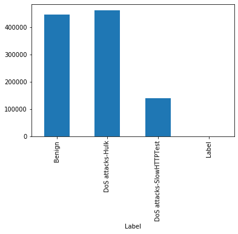

|  | Label | count |
| --- | --- | --- |
| 0 | Benign | 446772 |
| 1 | DoS attacks-Hulk | 461912 |
| 2 | DoS attacks-SlowHTTPTest | 139890 |
| 3 | Label | 1 |

```
0    4.260754e-01
1    4.405140e-01
2    1.334096e-01
3    9.536752e-07
dtype: float64
```

```
DataFrame only missing values, shape (438027, 20)
```

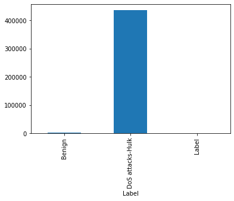

|  | Label | count |
| --- | --- | --- |
| 0 | Benign | 1926 |
| 1 | DoS attacks-Hulk | 436100 |
| 2 | Label | 1 |

```
0    0.004397
1    0.995601
2    0.000002
dtype: float64
```

```
DataFrame only missing values, shape (438027, 20)
```

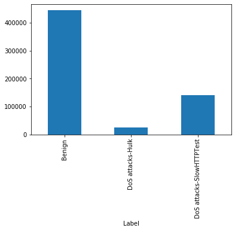

|  | Label | count |
| --- | --- | --- |
| 0 | Benign | 444846 |
| 1 | DoS attacks-Hulk | 25812 |
| 2 | DoS attacks-SlowHTTPTest | 139890 |

```
0    0.728601
1    0.042277
2    0.229122
dtype: float64
```

```
DataFrame after missing values removal, shape (610548, 20)
```

|  | count | mean | std | min | 25% | 50% | 75% | max |
| --- | --- | --- | --- | --- | --- | --- | --- | --- |
| Flow Duration | 610548.0 | 4.139883e+06 | 7.486029e+06 | 1.0 | 49528.75 | 4216831.5 | 4433755.75 | 112641773.0 |
| TotLen Fwd Pkts | 610548.0 | 6.930354e+02 | 4.008065e+02 | 0.0 | 341.00 | 935.0 | 935.00 | 16544.0 |
| TotLen Bwd Pkts | 610548.0 | 3.301963e+02 | 2.853256e+03 | 0.0 | 293.00 | 341.0 | 370.00 | 1566268.0 |
| Fwd Pkt Len Std | 610548.0 | 3.119801e+02 | 1.787660e+02 | 0.0 | 178.00 | 418.0 | 418.00 | 600.0 |
| Bwd Pkt Len Max | 610548.0 | 2.898699e+02 | 2.010773e+02 | 0.0 | 292.00 | 335.0 | 363.00 | 8688.0 |
| Bwd Pkt Len Std | 610548.0 | 1.600290e+02 | 1.035251e+02 | 0.0 | 151.00 | 188.0 | 207.00 | 1243.0 |
| Flow Byts/s | 610548.0 | 1.396573e+03 | 1.315166e+04 | 0.0 | 196.00 | 293.0 | 310.00 | 1730137.0 |
| Flow Pkts/s | 610548.0 | 1.683488e+05 | 3.444093e+05 | 0.0 | 2.00 | 2.0 | 136.00 | 2000000.0 |
| Flow IAT Max | 610548.0 | 4.006152e+06 | 7.414618e+06 | 1.0 | 38761.75 | 4107404.0 | 4264239.00 | 91300000.0 |
| Bwd IAT Min | 610548.0 | 5.384431e+03 | 1.972129e+05 | 0.0 | 27.00 | 376.0 | 5624.00 | 91300000.0 |
| Bwd Header Len | 610548.0 | 9.465073e+01 | 6.937572e+01 | 0.0 | 104.00 | 104.0 | 104.00 | 28456.0 |
| Pkt Len Max | 610548.0 | 7.166050e+02 | 3.961080e+02 | 0.0 | 935.00 | 935.0 | 935.00 | 8688.0 |
| Pkt Len Std | 610548.0 | 2.414929e+02 | 1.336025e+02 | 0.0 | 291.00 | 316.0 | 319.00 | 1288.0 |
| RST Flag Cnt | 610548.0 | 4.913619e-06 | 2.216665e-03 | 0.0 | 0.00 | 0.0 | 0.00 | 1.0 |
| PSH Flag Cnt | 610548.0 | 2.524765e-01 | 4.344334e-01 | 0.0 | 0.00 | 0.0 | 1.00 | 1.0 |
| ECE Flag Cnt | 610548.0 | 4.913619e-06 | 2.216665e-03 | 0.0 | 0.00 | 0.0 | 0.00 | 1.0 |
| Init Fwd Win Byts | 610548.0 | 6.956276e+03 | 1.158365e+04 | -1.0 | 219.00 | 237.0 | 26883.00 | 58856.0 |
| Init Bwd Win Byts | 610548.0 | 1.638622e+02 | 1.017372e+02 | -1.0 | 211.00 | 211.0 | 211.00 | 26883.0 |
| Fwd Seg Size Min | 610548.0 | 3.378600e+01 | 3.475948e+00 | 0.0 | 32.00 | 32.0 | 32.00 | 40.0 |

```
################################################################################
New datafile: cse-cic-ids2018/Friday-23-02-2018_TrafficForML_CICFlowMeter.csv
################################################################################
DataFrame before cleaning
```

|  | count | mean | std | min | 25% | 50% | 75% | max |
| --- | --- | --- | --- | --- | --- | --- | --- | --- |
| Flow Duration | 1048575.0 | 1.872781e+07 | 3.633651e+07 | 0.000000 | 512.000000 | 95118.000000 | 5.284498e+06 | 1.200000e+08 |
| TotLen Fwd Pkts | 1048575.0 | 4.139611e+02 | 2.152351e+03 | 0.000000 | 0.000000 | 45.000000 | 4.550000e+02 | 1.582330e+06 |
| TotLen Bwd Pkts | 1048575.0 | 9.754156e+03 | 4.400548e+05 | 0.000000 | 0.000000 | 101.000000 | 6.995000e+02 | 1.563604e+08 |
| Fwd Pkt Len Std | 1048575.0 | 5.634453e+01 | 8.955282e+01 | 0.000000 | 0.000000 | 0.000000 | 9.218699e+01 | 1.405737e+03 |
| Bwd Pkt Len Max | 1048575.0 | 3.688990e+02 | 5.203575e+02 | 0.000000 | 0.000000 | 95.000000 | 4.880000e+02 | 4.012000e+03 |
| Bwd Pkt Len Std | 1048575.0 | 1.306667e+02 | 2.064388e+02 | 0.000000 | 0.000000 | 0.000000 | 2.440000e+02 | 2.316329e+03 |
| Flow Byts/s | 1044821.0 | inf | NaN | 0.000000 | 0.000000 | 783.262429 | 5.458631e+04 | inf |
| Flow Pkts/s | 1048575.0 | inf | NaN | 0.016668 | 2.269405 | 49.393692 | 6.006006e+03 | inf |
| Flow IAT Max | 1048575.0 | 1.192801e+07 | 2.621886e+07 | 0.000000 | 348.000000 | 65553.000000 | 4.898036e+06 | 1.199916e+08 |
| Bwd IAT Min | 1048575.0 | 1.354203e+05 | 2.089117e+06 | 0.000000 | 0.000000 | 0.000000 | 1.890000e+02 | 1.199444e+08 |
| Bwd Header Len | 1048575.0 | 2.035038e+02 | 6.262350e+03 | 0.000000 | 0.000000 | 16.000000 | 1.480000e+02 | 2.462372e+06 |
| Pkt Len Max | 1048575.0 | 3.778671e+02 | 5.213480e+02 | 0.000000 | 0.000000 | 96.000000 | 5.430000e+02 | 6.592000e+03 |
| Pkt Len Std | 1048575.0 | 1.140112e+02 | 1.626785e+02 | 0.000000 | 0.000000 | 32.331615 | 1.737876e+02 | 1.328395e+03 |
| RST Flag Cnt | 1048575.0 | 1.164905e-01 | 3.208123e-01 | 0.000000 | 0.000000 | 0.000000 | 0.000000e+00 | 1.000000e+00 |
| PSH Flag Cnt | 1048575.0 | 3.791765e-01 | 4.851823e-01 | 0.000000 | 0.000000 | 0.000000 | 1.000000e+00 | 1.000000e+00 |
| ECE Flag Cnt | 1048575.0 | 1.164886e-01 | 3.208100e-01 | 0.000000 | 0.000000 | 0.000000 | 0.000000e+00 | 1.000000e+00 |
| Init Fwd Win Byts | 1048575.0 | 8.923638e+03 | 1.733627e+04 | -1.000000 | -1.000000 | 288.000000 | 8.192000e+03 | 6.553500e+04 |
| Init Bwd Win Byts | 1048575.0 | 1.020117e+04 | 2.266802e+04 | -1.000000 | -1.000000 | -1.000000 | 2.560000e+02 | 6.553500e+04 |
| Fwd Seg Size Min | 1048575.0 | 1.640559e+01 | 5.843276e+00 | 0.000000 | 8.000000 | 20.000000 | 2.000000e+01 | 4.800000e+01 |

```
DataFrame before missing values removal, shape (1048575, 20)
```

|  | Label | count |
| --- | --- | --- |
| 0 | Benign | 1048009 |
| 1 | Brute Force -Web | 362 |
| 2 | Brute Force -XSS | 151 |
| 3 | SQL Injection | 53 |

```
0    0.999460
1    0.000345
2    0.000144
3    0.000051
dtype: float64
```

```
DataFrame only missing values, shape (573167, 20)
```

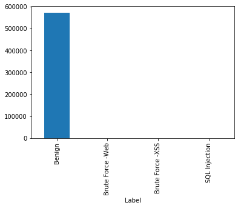

|  | Label | count |
| --- | --- | --- |
| 0 | Benign | 572834 |
| 1 | Brute Force -Web | 237 |
| 2 | Brute Force -XSS | 78 |
| 3 | SQL Injection | 18 |

```
0    0.999419
1    0.000413
2    0.000136
3    0.000031
dtype: float64
```

```
DataFrame only missing values, shape (573167, 20)
```

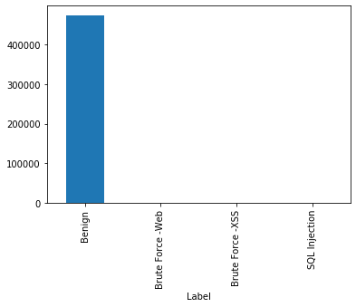

|  | Label | count |
| --- | --- | --- |
| 0 | Benign | 475016 |
| 1 | Brute Force -Web | 125 |
| 2 | Brute Force -XSS | 73 |
| 3 | SQL Injection | 35 |

```
0    0.999510
1    0.000263
2    0.000154
3    0.000074
dtype: float64
```

```
DataFrame after missing values removal, shape (475249, 20)
```

|  | count | mean | std | min | 25% | 50% | 75% | max |
| --- | --- | --- | --- | --- | --- | --- | --- | --- |
| Flow Duration | 475249.0 | 1.971589e+07 | 3.840013e+07 | 1.0 | 107036.0 | 2761539.0 | 5814053.0 | 119999967.0 |
| TotLen Fwd Pkts | 475249.0 | 8.666441e+02 | 3.133311e+03 | 0.0 | 97.0 | 597.0 | 1156.0 | 1582330.0 |
| TotLen Bwd Pkts | 475249.0 | 2.143635e+04 | 6.534603e+05 | 0.0 | 231.0 | 1581.0 | 1731.0 | 156360426.0 |
| Fwd Pkt Len Std | 475249.0 | 1.226308e+02 | 9.786797e+01 | 0.0 | 48.0 | 93.0 | 197.0 | 1406.0 |
| Bwd Pkt Len Max | 475249.0 | 7.518492e+02 | 5.695945e+02 | 0.0 | 156.0 | 1068.0 | 1179.0 | 4012.0 |
| Bwd Pkt Len Std | 475249.0 | 2.881594e+02 | 2.204842e+02 | 0.0 | 70.0 | 363.0 | 430.0 | 2316.0 |
| Flow Byts/s | 475249.0 | 1.587610e+05 | 2.545616e+06 | 0.0 | 53.0 | 760.0 | 1332.0 | 105290598.0 |
| Flow Pkts/s | 475249.0 | 1.179876e+04 | 8.961757e+04 | 0.0 | 2.0 | 6.0 | 82.0 | 3000000.0 |
| Flow IAT Max | 475249.0 | 6.529245e+06 | 1.547851e+07 | 1.0 | 58865.0 | 953140.0 | 5489309.0 | 119911774.0 |
| Bwd IAT Min | 475249.0 | 2.110327e+05 | 2.240971e+06 | 0.0 | 0.0 | 154.0 | 108167.0 | 107560522.0 |
| Bwd Header Len | 475249.0 | 4.429657e+02 | 9.296361e+03 | 20.0 | 92.0 | 152.0 | 172.0 | 2462372.0 |
| Pkt Len Max | 475249.0 | 7.661949e+02 | 5.644774e+02 | 0.0 | 197.0 | 1173.0 | 1179.0 | 6592.0 |
| Pkt Len Std | 475249.0 | 2.287537e+02 | 1.829961e+02 | 0.0 | 69.0 | 274.0 | 319.0 | 1328.0 |
| RST Flag Cnt | 475249.0 | 2.570042e-01 | 4.369822e-01 | 0.0 | 0.0 | 0.0 | 1.0 | 1.0 |
| PSH Flag Cnt | 475249.0 | 8.342721e-01 | 3.718366e-01 | 0.0 | 1.0 | 1.0 | 1.0 | 1.0 |
| ECE Flag Cnt | 475249.0 | 2.570042e-01 | 4.369822e-01 | 0.0 | 0.0 | 0.0 | 1.0 | 1.0 |
| Init Fwd Win Byts | 475249.0 | 7.607645e+03 | 5.910074e+03 | 0.0 | 8192.0 | 8192.0 | 8192.0 | 65535.0 |
| Init Bwd Win Byts | 475249.0 | 2.250849e+04 | 2.926904e+04 | 0.0 | 149.0 | 288.0 | 62643.0 | 65535.0 |
| Fwd Seg Size Min | 475249.0 | 2.009613e+01 | 1.064378e+00 | 20.0 | 20.0 | 20.0 | 20.0 | 48.0 |

```
################################################################################
New datafile: cse-cic-ids2018/Thuesday-20-02-2018_TrafficForML_CICFlowMeter.csv
################################################################################
DataFrame before cleaning
```

|  | count | mean | std | min | 25% | 50% | 75% | max |
| --- | --- | --- | --- | --- | --- | --- | --- | --- |
| Flow Duration | 7948748.0 | 1.353327e+07 | 3.243525e+07 | 0.000000 | 448.000000 | 52079.000000 | 3.170154e+06 | 1.200000e+08 |
| TotLen Fwd Pkts | 7948748.0 | 7.137929e+02 | 3.983634e+04 | 0.000000 | 11.000000 | 43.000000 | 3.910000e+02 | 8.961376e+06 |
| TotLen Bwd Pkts | 7948748.0 | 5.008268e+03 | 2.281501e+05 | 0.000000 | 0.000000 | 108.000000 | 9.640000e+02 | 3.758338e+07 |
| Fwd Pkt Len Std | 7948748.0 | 5.404863e+01 | 8.736557e+01 | 0.000000 | 0.000000 | 0.000000 | 8.515101e+01 | 1.032376e+03 |
| Bwd Pkt Len Max | 7948748.0 | 3.911664e+02 | 5.258034e+02 | 0.000000 | 0.000000 | 101.000000 | 9.640000e+02 | 6.516000e+04 |
| Bwd Pkt Len Std | 7948748.0 | 1.423066e+02 | 2.177747e+02 | 0.000000 | 0.000000 | 0.000000 | 3.725087e+02 | 2.244841e+04 |
| Flow Byts/s | 7911981.0 | inf | NaN | 0.000000 | 4.132384 | 1102.432985 | 9.490334e+04 | inf |
| Flow Pkts/s | 7948748.0 | inf | NaN | 0.016667 | 4.582168 | 77.697059 | 5.747126e+03 | inf |
| Flow IAT Max | 7948748.0 | 6.341763e+06 | 1.643412e+07 | 0.000000 | 364.000000 | 37182.000000 | 1.434202e+06 | 1.200000e+08 |
| Bwd IAT Min | 7948748.0 | 4.119667e+05 | 4.575362e+06 | 0.000000 | 0.000000 | 0.000000 | 4.100000e+01 | 1.199638e+08 |
| Bwd Header Len | 7948748.0 | 1.383826e+02 | 3.161772e+03 | 0.000000 | 8.000000 | 16.000000 | 1.120000e+02 | 5.161320e+05 |
| Pkt Len Max | 7948748.0 | 3.992410e+02 | 5.254275e+02 | 0.000000 | 22.000000 | 101.000000 | 9.640000e+02 | 6.516000e+04 |
| Pkt Len Std | 7948748.0 | 1.228508e+02 | 1.641155e+02 | 0.000000 | 0.000000 | 35.218366 | 2.864777e+02 | 2.246389e+04 |
| RST Flag Cnt | 7948748.0 | 2.120984e-01 | 4.087942e-01 | 0.000000 | 0.000000 | 0.000000 | 0.000000e+00 | 1.000000e+00 |
| PSH Flag Cnt | 7948748.0 | 3.908267e-01 | 4.879357e-01 | 0.000000 | 0.000000 | 0.000000 | 1.000000e+00 | 1.000000e+00 |
| ECE Flag Cnt | 7948748.0 | 2.121002e-01 | 4.087955e-01 | 0.000000 | 0.000000 | 0.000000 | 0.000000e+00 | 1.000000e+00 |
| Init Fwd Win Byts | 7948748.0 | 5.076764e+03 | 1.025962e+04 | -1.000000 | -1.000000 | 279.000000 | 8.192000e+03 | 6.553500e+04 |
| Init Bwd Win Byts | 7948748.0 | 9.624548e+03 | 2.200057e+04 | -1.000000 | -1.000000 | -1.000000 | 2.550000e+02 | 6.553500e+04 |
| Fwd Seg Size Min | 7948748.0 | 1.597078e+01 | 6.187313e+00 | 0.000000 | 8.000000 | 20.000000 | 2.000000e+01 | 4.800000e+01 |

```
DataFrame before missing values removal, shape (7948748, 20)
```

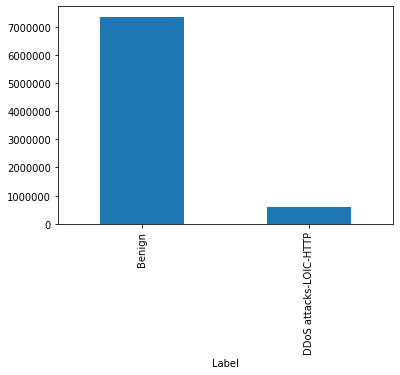

|  | Label | count |
| --- | --- | --- |
| 0 | Benign | 7372557 |
| 1 | DDoS attacks-LOIC-HTTP | 576191 |

```
0    0.927512
1    0.072488
dtype: float64
```

```
DataFrame only missing values, shape (4209795, 20)
```

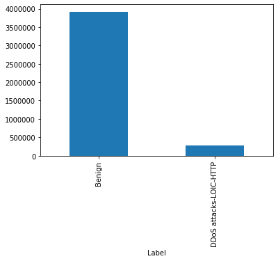

|  | Label | count |
| --- | --- | --- |
| 0 | Benign | 3922893 |
| 1 | DDoS attacks-LOIC-HTTP | 286902 |

```
0    0.931849
1    0.068151
dtype: float64
```

```
DataFrame only missing values, shape (4209795, 20)
```

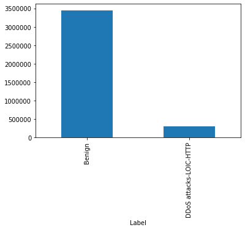

|  | Label | count |
| --- | --- | --- |
| 0 | Benign | 3448885 |
| 1 | DDoS attacks-LOIC-HTTP | 289289 |

```
0    0.922612
1    0.077388
dtype: float64
```

```
DataFrame after missing values removal, shape (3738174, 20)
```

|  | count | mean | std | min | 25% | 50% | 75% | max |
| --- | --- | --- | --- | --- | --- | --- | --- | --- |
| Flow Duration | 3738174.0 | 2.037625e+07 | 3.929724e+07 | 1.0 | 188677.25 | 1889399.0 | 6032630.25 | 120000000.0 |
| TotLen Fwd Pkts | 3738174.0 | 7.125010e+02 | 3.201393e+03 | 0.0 | 31.00 | 455.0 | 1144.00 | 1994167.0 |
| TotLen Bwd Pkts | 3738174.0 | 1.055116e+04 | 3.326022e+05 | 0.0 | 170.00 | 971.0 | 1640.00 | 37583377.0 |
| Fwd Pkt Len Std | 3738174.0 | 1.129930e+02 | 9.793173e+01 | 0.0 | 18.00 | 89.0 | 205.00 | 1032.0 |
| Bwd Pkt Len Max | 3738174.0 | 7.643928e+02 | 5.661835e+02 | 0.0 | 131.00 | 964.0 | 1173.00 | 65160.0 |
| Bwd Pkt Len Std | 3738174.0 | 3.024720e+02 | 2.288516e+02 | 0.0 | 62.00 | 399.0 | 482.00 | 22448.0 |
| Flow Byts/s | 3738174.0 | 1.152700e+05 | 2.405756e+06 | 0.0 | 48.00 | 697.0 | 1385.00 | 916078431.0 |
| Flow Pkts/s | 3738174.0 | 1.229488e+04 | 7.809153e+04 | 0.0 | 2.00 | 7.0 | 32.00 | 3000000.0 |
| Flow IAT Max | 3738174.0 | 7.400292e+06 | 1.632750e+07 | 1.0 | 119349.25 | 953204.0 | 5489965.50 | 119951852.0 |
| Bwd IAT Min | 3738174.0 | 7.603819e+05 | 6.156043e+06 | 0.0 | 0.00 | 29.0 | 104416.00 | 119956094.0 |
| Bwd Header Len | 3738174.0 | 2.873582e+02 | 4.605878e+03 | 20.0 | 92.00 | 148.0 | 180.00 | 516132.0 |
| Pkt Len Max | 3738174.0 | 7.775942e+02 | 5.591389e+02 | 0.0 | 131.00 | 964.0 | 1173.00 | 65160.0 |
| Pkt Len Std | 3738174.0 | 2.367749e+02 | 1.789632e+02 | 0.0 | 53.00 | 295.0 | 340.00 | 22464.0 |
| RST Flag Cnt | 3738174.0 | 4.477330e-01 | 4.972607e-01 | 0.0 | 0.00 | 0.0 | 1.00 | 1.0 |
| PSH Flag Cnt | 3738174.0 | 8.195124e-01 | 3.845931e-01 | 0.0 | 1.00 | 1.0 | 1.00 | 1.0 |
| ECE Flag Cnt | 3738174.0 | 4.477379e-01 | 4.972612e-01 | 0.0 | 0.00 | 0.0 | 1.00 | 1.0 |
| Init Fwd Win Byts | 3738174.0 | 7.955044e+03 | 8.044727e+03 | 0.0 | 8192.00 | 8192.0 | 8192.00 | 65535.0 |
| Init Bwd Win Byts | 3738174.0 | 2.046623e+04 | 2.841324e+04 | 0.0 | 149.00 | 256.0 | 62852.00 | 65535.0 |
| Fwd Seg Size Min | 3738174.0 | 2.009175e+01 | 9.654116e-01 | 20.0 | 20.00 | 20.0 | 20.00 | 48.0 |

```
################################################################################
New datafile: cse-cic-ids2018/Thursday-01-03-2018_TrafficForML_CICFlowMeter.csv
################################################################################
```

```
DataFrame before cleaning
```

|  | count | unique | top | freq |
| --- | --- | --- | --- | --- |
| Flow Duration | 331125 | 159256 | 2 | 7258 |
| TotLen Fwd Pkts | 331125 | 5599 | 0 | 76892 |
| TotLen Bwd Pkts | 331125 | 10875 | 0 | 96519 |
| Fwd Pkt Len Std | 331125 | 15816 | 0 | 172890 |
| Bwd Pkt Len Max | 331125 | 1270 | 0 | 96519 |
| Bwd Pkt Len Std | 331125 | 16435 | 0 | 193188 |
| Flow Byts/s | 329291 | 177796 | 0 | 75299 |
| Flow Pkts/s | 331125 | 161005 | 1000000 | 7243 |
| Flow IAT Max | 331125 | 90505 | 10000000 | 8235 |
| Bwd IAT Min | 331125 | 54558 | 0 | 179613 |
| Bwd Header Len | 331125 | 1275 | 8 | 79050 |
| Pkt Len Max | 331125 | 1530 | 0 | 76782 |
| Pkt Len Std | 331125 | 24017 | 0 | 78688 |
| RST Flag Cnt | 331125 | 5 | 0 | 215308 |
| PSH Flag Cnt | 331125 | 5 | 0 | 158934 |
| ECE Flag Cnt | 331125 | 5 | 0 | 215307 |
| Init Fwd Win Byts | 331125 | 2886 | -1 | 100270 |
| Init Bwd Win Byts | 331125 | 2787 | -1 | 134884 |
| Fwd Seg Size Min | 331125 | 19 | 20 | 137995 |
| Label | 331125 | 3 | Benign | 238037 |

```
DataFrame before missing values removal, shape (331125, 20)
```

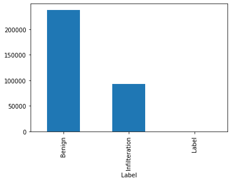

|  | Label | count |
| --- | --- | --- |
| 0 | Benign | 238037 |
| 1 | Infilteration | 93063 |
| 2 | Label | 25 |

```
0    0.718874
1    0.281051
2    0.000076
dtype: float64
```

```
DataFrame only missing values, shape (135260, 20)
```

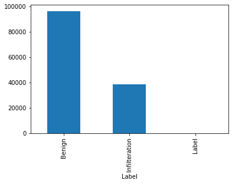

|  | Label | count |
| --- | --- | --- |
| 0 | Benign | 96455 |
| 1 | Infilteration | 38780 |
| 2 | Label | 25 |

```
0    0.713108
1    0.286707
2    0.000185
dtype: float64
```

```
DataFrame only missing values, shape (135260, 20)
```

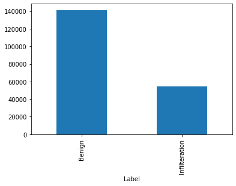

|  | Label | count |
| --- | --- | --- |
| 0 | Benign | 141323 |
| 1 | Infilteration | 54270 |

```
0    0.722536
1    0.277464
dtype: float64
```

```
DataFrame after missing values removal, shape (195593, 20)
```

|  | count | mean | std | min | 25% | 50% | 75% | max |
| --- | --- | --- | --- | --- | --- | --- | --- | --- |
| Flow Duration | 195593.0 | 1.952323e+07 | 3.972200e+07 | 1.0 | 247.0 | 471583.0 | 5185122.0 | 119999992.0 |
| TotLen Fwd Pkts | 195593.0 | 5.761479e+02 | 1.681583e+03 | 0.0 | 0.0 | 77.0 | 1128.0 | 162048.0 |
| TotLen Bwd Pkts | 195593.0 | 5.255782e+03 | 2.692398e+05 | 0.0 | 0.0 | 114.0 | 1581.0 | 38600000.0 |
| Fwd Pkt Len Std | 195593.0 | 8.278673e+01 | 1.039847e+02 | 0.0 | 0.0 | 23.0 | 189.0 | 1324.0 |
| Bwd Pkt Len Max | 195593.0 | 4.941902e+02 | 6.165464e+02 | 0.0 | 0.0 | 99.0 | 1173.0 | 65160.0 |
| Bwd Pkt Len Std | 195593.0 | 1.848687e+02 | 2.434496e+02 | 0.0 | 0.0 | 0.0 | 430.0 | 21326.0 |
| Flow Byts/s | 195593.0 | 1.568556e+05 | 3.193866e+06 | 0.0 | 0.0 | 76.0 | 1605.0 | 708000000.0 |
| Flow Pkts/s | 195593.0 | 1.108300e+05 | 3.282708e+05 | 0.0 | 3.0 | 15.0 | 8230.0 | 3000000.0 |
| Flow IAT Max | 195593.0 | 6.972767e+06 | 1.640932e+07 | 1.0 | 246.0 | 236940.0 | 4209573.0 | 120000000.0 |
| Bwd IAT Min | 195593.0 | 4.090112e+05 | 3.892291e+06 | 0.0 | 0.0 | 0.0 | 63284.0 | 120000000.0 |
| Bwd Header Len | 195593.0 | 1.863650e+02 | 3.743662e+03 | 0.0 | 20.0 | 52.0 | 152.0 | 531332.0 |
| Pkt Len Max | 195593.0 | 5.208234e+02 | 6.149227e+02 | 0.0 | 0.0 | 125.0 | 1173.0 | 65160.0 |
| Pkt Len Std | 195593.0 | 1.541270e+02 | 1.939388e+02 | 0.0 | 0.0 | 39.0 | 318.0 | 22788.0 |
| RST Flag Cnt | 195593.0 | 3.311315e-01 | 4.706215e-01 | 0.0 | 0.0 | 0.0 | 1.0 | 1.0 |
| PSH Flag Cnt | 195593.0 | 7.190697e-01 | 4.494547e-01 | 0.0 | 0.0 | 1.0 | 1.0 | 1.0 |
| ECE Flag Cnt | 195593.0 | 3.311315e-01 | 4.706215e-01 | 0.0 | 0.0 | 0.0 | 1.0 | 1.0 |
| Init Fwd Win Byts | 195593.0 | 5.741485e+03 | 8.340871e+03 | -1.0 | 980.0 | 8192.0 | 8192.0 | 65535.0 |
| Init Bwd Win Byts | 195593.0 | 1.492918e+04 | 2.594450e+04 | -1.0 | 0.0 | 172.0 | 8192.0 | 65535.0 |
| Fwd Seg Size Min | 195593.0 | 1.993560e+01 | 4.991516e+00 | 0.0 | 20.0 | 20.0 | 20.0 | 48.0 |

```
################################################################################
New datafile: cse-cic-ids2018/Thursday-15-02-2018_TrafficForML_CICFlowMeter.csv
################################################################################
DataFrame before cleaning
```

|  | count | mean | std | min | 25% | 50% | 75% | max |
| --- | --- | --- | --- | --- | --- | --- | --- | --- |
| Flow Duration | 1048575.0 | 1.430739e+07 | 3.335503e+07 | 0.000000 | 413.000000 | 36896.000000 | 3.377079e+06 | 1.200000e+08 |
| TotLen Fwd Pkts | 1048575.0 | 4.354262e+02 | 2.881334e+04 | 0.000000 | 0.000000 | 44.000000 | 3.330000e+02 | 8.737314e+06 |
| TotLen Bwd Pkts | 1048575.0 | 4.925884e+03 | 1.399474e+05 | 0.000000 | 0.000000 | 99.000000 | 4.880000e+02 | 2.790523e+07 |
| Fwd Pkt Len Std | 1048575.0 | 5.079972e+01 | 9.133395e+01 | 0.000000 | 0.000000 | 0.000000 | 8.192355e+01 | 1.840158e+04 |
| Bwd Pkt Len Max | 1048575.0 | 3.305074e+02 | 4.938690e+02 | 0.000000 | 0.000000 | 90.000000 | 4.090000e+02 | 2.708000e+03 |
| Bwd Pkt Len Std | 1048575.0 | 1.204887e+02 | 2.068673e+02 | 0.000000 | 0.000000 | 0.000000 | 1.670353e+02 | 1.329361e+03 |
| Flow Byts/s | 1043654.0 | inf | NaN | 0.000000 | 0.000000 | 1031.362899 | 9.054805e+04 | inf |
| Flow Pkts/s | 1048575.0 | inf | NaN | 0.016668 | 2.389973 | 97.406551 | 6.410256e+03 | inf |
| Flow IAT Max | 1048575.0 | 6.777187e+06 | 1.730306e+07 | 0.000000 | 328.000000 | 30423.000000 | 1.929832e+06 | 1.199915e+08 |
| Bwd IAT Min | 1048575.0 | 6.486163e+05 | 6.418770e+06 | 0.000000 | 0.000000 | 0.000000 | 2.200000e+01 | 1.199131e+08 |
| Bwd Header Len | 1048575.0 | 1.345203e+02 | 1.962800e+03 | 0.000000 | 8.000000 | 8.000000 | 1.000000e+02 | 3.836320e+05 |
| Pkt Len Max | 1048575.0 | 3.402048e+02 | 5.127492e+02 | 0.000000 | 0.000000 | 95.000000 | 4.880000e+02 | 6.444000e+04 |
| Pkt Len Std | 1048575.0 | 1.096400e+02 | 1.636579e+02 | 0.000000 | 0.000000 | 32.331615 | 1.545861e+02 | 1.057981e+04 |
| RST Flag Cnt | 1048575.0 | 6.098658e-02 | 2.393058e-01 | 0.000000 | 0.000000 | 0.000000 | 0.000000e+00 | 1.000000e+00 |
| PSH Flag Cnt | 1048575.0 | 3.634781e-01 | 4.810010e-01 | 0.000000 | 0.000000 | 0.000000 | 1.000000e+00 | 1.000000e+00 |
| ECE Flag Cnt | 1048575.0 | 6.098467e-02 | 2.393023e-01 | 0.000000 | 0.000000 | 0.000000 | 0.000000e+00 | 1.000000e+00 |
| Init Fwd Win Byts | 1048575.0 | 5.221909e+03 | 1.053626e+04 | -1.000000 | -1.000000 | 257.000000 | 8.192000e+03 | 6.553500e+04 |
| Init Bwd Win Byts | 1048575.0 | 5.600345e+03 | 1.712450e+04 | -1.000000 | -1.000000 | -1.000000 | 2.190000e+02 | 6.553500e+04 |
| Fwd Seg Size Min | 1048575.0 | 1.659039e+01 | 7.476644e+00 | 0.000000 | 8.000000 | 20.000000 | 2.000000e+01 | 5.600000e+01 |

```
DataFrame before missing values removal, shape (1048575, 20)
```

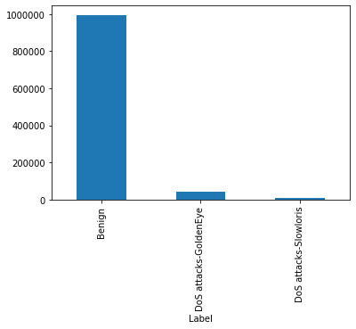

|  | Label | count |
| --- | --- | --- |
| 0 | Benign | 996077 |
| 1 | DoS attacks-GoldenEye | 41508 |
| 2 | DoS attacks-Slowloris | 10990 |

```
0    0.949934
1    0.039585
2    0.010481
dtype: float64
```

```
DataFrame only missing values, shape (587584, 20)
```

[13 more figures not shown]

|  | Label | count |
| --- | --- | --- |
| 0 | Benign | 353364 |
| 1 | Infilteration | 42743 |

```
0    0.892092
1    0.107908
dtype: float64
```

```
DataFrame after missing values removal, shape (396107, 20)
```

|  | count | mean | std | min | 25% | 50% | 75% | max |
| --- | --- | --- | --- | --- | --- | --- | --- | --- |
| Flow Duration | 396107.0 | 1.793684e+07 | 3.808248e+07 | 1.0 | 248.0 | 94503.0 | 5414140.0 | 119999957.0 |
| TotLen Fwd Pkts | 396107.0 | 6.301886e+02 | 2.578076e+04 | 0.0 | 0.0 | 51.0 | 864.0 | 13486697.0 |
| TotLen Bwd Pkts | 396107.0 | 5.165306e+03 | 2.411006e+05 | 0.0 | 0.0 | 96.0 | 1581.0 | 34937934.0 |
| Fwd Pkt Len Std | 396107.0 | 7.734364e+01 | 1.068432e+02 | 0.0 | 0.0 | 18.0 | 150.0 | 3311.0 |
| Bwd Pkt Len Max | 396107.0 | 4.831506e+02 | 6.169867e+02 | 0.0 | 0.0 | 84.0 | 1173.0 | 31469.0 |
| Bwd Pkt Len Std | 396107.0 | 1.832011e+02 | 2.528880e+02 | 0.0 | 0.0 | 0.0 | 430.0 | 1329.0 |
| Flow Byts/s | 396107.0 | 1.994750e+05 | 2.958574e+06 | 0.0 | 0.0 | 212.0 | 6510.0 | 247000000.0 |
| Flow Pkts/s | 396107.0 | 9.527323e+04 | 3.205069e+05 | 0.0 | 3.0 | 67.0 | 8547.0 | 3000000.0 |
| Flow IAT Max | 396107.0 | 6.503370e+06 | 1.532978e+07 | 1.0 | 241.0 | 56362.0 | 4953750.0 | 119455389.0 |
| Bwd IAT Min | 396107.0 | 3.785503e+05 | 3.918350e+06 | 0.0 | 0.0 | 0.0 | 26.0 | 118163443.0 |
| Bwd Header Len | 396107.0 | 1.726541e+02 | 3.370336e+03 | 0.0 | 16.0 | 20.0 | 156.0 | 485592.0 |
| Pkt Len Max | 396107.0 | 5.040203e+02 | 6.152951e+02 | 0.0 | 0.0 | 97.0 | 1173.0 | 31469.0 |
| Pkt Len Std | 396107.0 | 1.568290e+02 | 1.985661e+02 | 0.0 | 0.0 | 32.0 | 318.0 | 2806.0 |
| RST Flag Cnt | 396107.0 | 3.483958e-01 | 4.764627e-01 | 0.0 | 0.0 | 0.0 | 1.0 | 1.0 |
| PSH Flag Cnt | 396107.0 | 5.917012e-01 | 4.915196e-01 | 0.0 | 0.0 | 1.0 | 1.0 | 1.0 |
| ECE Flag Cnt | 396107.0 | 3.483907e-01 | 4.764611e-01 | 0.0 | 0.0 | 0.0 | 1.0 | 1.0 |
| Init Fwd Win Byts | 396107.0 | 6.008027e+03 | 1.115807e+04 | -1.0 | 219.0 | 1024.0 | 8192.0 | 65535.0 |
| Init Bwd Win Byts | 396107.0 | 1.003776e+04 | 2.159326e+04 | -1.0 | -1.0 | 60.0 | 4699.0 | 65535.0 |
| Fwd Seg Size Min | 396107.0 | 1.871358e+01 | 5.700879e+00 | 0.0 | 20.0 | 20.0 | 20.0 | 44.0 |

```python
for dataset_file in sorted(glob(f'{dataset_name}/*.csv')):
  file_name = dataset_file.split('/')[-1]
  print('#' * 80)
  print('New datafile:', dataset_file)
  print('#' * 80)
  df = pd.read_csv(dataset_file, usecols=selected_features_common + ['Label'])
  df = clean.get_clean_df(df, verbose=1)
  df.to_csv(f'{dataset_name_clean}/{file_name}', index=False)
```

```python
!ls -al $dataset_name_clean
```

```
total 640536
drwxrwxr-x  2 ec2-user ec2-user      4096 Jan  3 19:13 .
drwxr-xr-x 10 ec2-user ec2-user      4096 Jan  3 19:14 ..
-rw-rw-r--  1 ec2-user ec2-user  43375773 Jan  3 19:11 Friday-02-03-2018_TrafficForML_CICFlowMeter.csv
-rw-rw-r--  1 ec2-user ec2-user  49622256 Jan  3 19:11 Friday-16-02-2018_TrafficForML_CICFlowMeter.csv
-rw-rw-r--  1 ec2-user ec2-user  38558811 Jan  3 19:11 Friday-23-02-2018_TrafficForML_CICFlowMeter.csv
-rw-rw-r--  1 ec2-user ec2-user 306445922 Jan  3 19:12 Thuesday-20-02-2018_TrafficForML_CICFlowMeter.csv
-rw-rw-r--  1 ec2-user ec2-user  14774621 Jan  3 19:12 Thursday-01-03-2018_TrafficForML_CICFlowMeter.csv
-rw-rw-r--  1 ec2-user ec2-user  37085528 Jan  3 19:12 Thursday-15-02-2018_TrafficForML_CICFlowMeter.csv
-rw-rw-r--  1 ec2-user ec2-user  38162420 Jan  3 19:13 Thursday-22-02-2018_TrafficForML_CICFlowMeter.csv
-rw-rw-r--  1 ec2-user ec2-user  53203304 Jan  3 19:13 Wednesday-14-02-2018_TrafficForML_CICFlowMeter.csv
-rw-rw-r--  1 ec2-user ec2-user  45629844 Jan  3 19:13 Wednesday-21-02-2018_TrafficForML_CICFlowMeter.csv
-rw-rw-r--  1 ec2-user ec2-user  29021547 Jan  3 19:13 Wednesday-28-02-2018_TrafficForML_CICFlowMeter.csv
```

```python
!ls -alh $dataset_name_clean
```

```
total 626M
drwxrwxr-x  2 ec2-user ec2-user 4.0K Jan  3 19:13 .
drwxr-xr-x 10 ec2-user ec2-user 4.0K Jan  3 19:14 ..
-rw-rw-r--  1 ec2-user ec2-user  42M Jan  3 19:11 Friday-02-03-2018_TrafficForML_CICFlowMeter.csv
-rw-rw-r--  1 ec2-user ec2-user  48M Jan  3 19:11 Friday-16-02-2018_TrafficForML_CICFlowMeter.csv
-rw-rw-r--  1 ec2-user ec2-user  37M Jan  3 19:11 Friday-23-02-2018_TrafficForML_CICFlowMeter.csv
-rw-rw-r--  1 ec2-user ec2-user 293M Jan  3 19:12 Thuesday-20-02-2018_TrafficForML_CICFlowMeter.csv
-rw-rw-r--  1 ec2-user ec2-user  15M Jan  3 19:12 Thursday-01-03-2018_TrafficForML_CICFlowMeter.csv
-rw-rw-r--  1 ec2-user ec2-user  36M Jan  3 19:12 Thursday-15-02-2018_TrafficForML_CICFlowMeter.csv
-rw-rw-r--  1 ec2-user ec2-user  37M Jan  3 19:13 Thursday-22-02-2018_TrafficForML_CICFlowMeter.csv
-rw-rw-r--  1 ec2-user ec2-user  51M Jan  3 19:13 Wednesday-14-02-2018_TrafficForML_CICFlowMeter.csv
-rw-rw-r--  1 ec2-user ec2-user  44M Jan  3 19:13 Wednesday-21-02-2018_TrafficForML_CICFlowMeter.csv
-rw-rw-r--  1 ec2-user ec2-user  28M Jan  3 19:13 Wednesday-28-02-2018_TrafficForML_CICFlowMeter.csv
```

```python
!head -2 $dataset_name_clean/*.csv
```

```
==> cse-cic-ids2018-clean/Friday-02-03-2018_TrafficForML_CICFlowMeter.csv <==
Flow Duration,TotLen Fwd Pkts,TotLen Bwd Pkts,Fwd Pkt Len Std,Bwd Pkt Len Max,Bwd Pkt Len Std,Flow Byts/s,Flow Pkts/s,Flow IAT Max,Bwd IAT Min,Bwd Header Len,Pkt Len Max,Pkt Len Std,RST Flag Cnt,PSH Flag Cnt,ECE Flag Cnt,Init Fwd Win Byts,Init Bwd Win Byts,Fwd Seg Size Min,Label
141385,553,3773,88,1460,655,30597,113,73403,1,152,1460,475,1,1,1,8192,119,20,Benign

==> cse-cic-ids2018-clean/Friday-16-02-2018_TrafficForML_CICFlowMeter.csv <==
Flow Duration,TotLen Fwd Pkts,TotLen Bwd Pkts,Fwd Pkt Len Std,Bwd Pkt Len Max,Bwd Pkt Len Std,Flow Byts/s,Flow Pkts/s,Flow IAT Max,Bwd IAT Min,Bwd Header Len,Pkt Len Max,Pkt Len Std,RST Flag Cnt,PSH Flag Cnt,ECE Flag Cnt,Init Fwd Win Byts,Init Bwd Win Byts,Fwd Seg Size Min,Label
20784143,2416,1344,55,64,32,181,3,9058214,41601,880,240,54,0,0,0,263,255,20,Benign

==> cse-cic-ids2018-clean/Friday-23-02-2018_TrafficForML_CICFlowMeter.csv <==
Flow Duration,TotLen Fwd Pkts,TotLen Bwd Pkts,Fwd Pkt Len Std,Bwd Pkt Len Max,Bwd Pkt Len Std,Flow Byts/s,Flow Pkts/s,Flow IAT Max,Bwd IAT Min,Bwd Header Len,Pkt Len Max,Pkt Len Std,RST Flag Cnt,PSH Flag Cnt,ECE Flag Cnt,Init Fwd Win Byts,Init Bwd Win Byts,Fwd Seg Size Min,Label
1532698,1179,1969,196,976,364,2054,14,207592,67,360,976,283,0,1,0,29200,230,32,Benign

==> cse-cic-ids2018-clean/Thuesday-20-02-2018_TrafficForML_CICFlowMeter.csv <==
Flow Duration,TotLen Fwd Pkts,TotLen Bwd Pkts,Fwd Pkt Len Std,Bwd Pkt Len Max,Bwd Pkt Len Std,Flow Byts/s,Flow Pkts/s,Flow IAT Max,Bwd IAT Min,Bwd Header Len,Pkt Len Max,Pkt Len Std,RST Flag Cnt,PSH Flag Cnt,ECE Flag Cnt,Init Fwd Win Byts,Init Bwd Win Byts,Fwd Seg Size Min,Label
888751,1249,1969,221,976,364,3621,25,101609,72,360,976,291,0,1,0,14600,233,32,Benign

==> cse-cic-ids2018-clean/Thursday-01-03-2018_TrafficForML_CICFlowMeter.csv <==
Flow Duration,TotLen Fwd Pkts,TotLen Bwd Pkts,Fwd Pkt Len Std,Bwd Pkt Len Max,Bwd Pkt Len Std,Flow Byts/s,Flow Pkts/s,Flow IAT Max,Bwd IAT Min,Bwd Header Len,Pkt Len Max,Pkt Len Std,RST Flag Cnt,PSH Flag Cnt,ECE Flag Cnt,Init Fwd Win Byts,Init Bwd Win Byts,Fwd Seg Size Min,Label
115307855,0,0,0,0,0,0,0,61000000,0,0,0,0,0,0,0,-1,-1,0,Benign

==> cse-cic-ids2018-clean/Thursday-15-02-2018_TrafficForML_CICFlowMeter.csv <==
Flow Duration,TotLen Fwd Pkts,TotLen Bwd Pkts,Fwd Pkt Len Std,Bwd Pkt Len Max,Bwd Pkt Len Std,Flow Byts/s,Flow Pkts/s,Flow IAT Max,Bwd IAT Min,Bwd Header Len,Pkt Len Max,Pkt Len Std,RST Flag Cnt,PSH Flag Cnt,ECE Flag Cnt,Init Fwd Win Byts,Init Bwd Win Byts,Fwd Seg Size Min,Label
37366762,2168,2993,255,976,396,138,1,15617415,893,416,976,320,0,1,0,29200,232,32,Benign

==> cse-cic-ids2018-clean/Thursday-22-02-2018_TrafficForML_CICFlowMeter.csv <==
Flow Duration,TotLen Fwd Pkts,TotLen Bwd Pkts,Fwd Pkt Len Std,Bwd Pkt Len Max,Bwd Pkt Len Std,Flow Byts/s,Flow Pkts/s,Flow IAT Max,Bwd IAT Min,Bwd Header Len,Pkt Len Max,Pkt Len Std,RST Flag Cnt,PSH Flag Cnt,ECE Flag Cnt,Init Fwd Win Byts,Init Bwd Win Byts,Fwd Seg Size Min,Label
20553406,1063,1297,239,976,363,115,1,19526080,2639,152,976,282,0,1,0,14600,222,20,Benign

==> cse-cic-ids2018-clean/Wednesday-14-02-2018_TrafficForML_CICFlowMeter.csv <==
Flow Duration,TotLen Fwd Pkts,TotLen Bwd Pkts,Fwd Pkt Len Std,Bwd Pkt Len Max,Bwd Pkt Len Std,Flow Byts/s,Flow Pkts/s,Flow IAT Max,Bwd IAT Min,Bwd Header Len,Pkt Len Max,Pkt Len Std,RST Flag Cnt,PSH Flag Cnt,ECE Flag Cnt,Init Fwd Win Byts,Init Bwd Win Byts,Fwd Seg Size Min,Label
6453966,1239,2273,197,976,372,544,4,673900,554,328,976,278,0,1,0,65535,233,32,Benign

==> cse-cic-ids2018-clean/Wednesday-21-02-2018_TrafficForML_CICFlowMeter.csv <==
Flow Duration,TotLen Fwd Pkts,TotLen Bwd Pkts,Fwd Pkt Len Std,Bwd Pkt Len Max,Bwd Pkt Len Std,Flow Byts/s,Flow Pkts/s,Flow IAT Max,Bwd IAT Min,Bwd Header Len,Pkt Len Max,Pkt Len Std,RST Flag Cnt,PSH Flag Cnt,ECE Flag Cnt,Init Fwd Win Byts,Init Bwd Win Byts,Fwd Seg Size Min,Label
37953,135,127,60,127,73,6903,211,12099,401,104,135,58,0,1,0,29200,219,32,Benign

==> cse-cic-ids2018-clean/Wednesday-28-02-2018_TrafficForML_CICFlowMeter.csv <==
Flow Duration,TotLen Fwd Pkts,TotLen Bwd Pkts,Fwd Pkt Len Std,Bwd Pkt Len Max,Bwd Pkt Len Std,Flow Byts/s,Flow Pkts/s,Flow IAT Max,Bwd IAT Min,Bwd Header Len,Pkt Len Max,Pkt Len Std,RST Flag Cnt,PSH Flag Cnt,ECE Flag Cnt,Init Fwd Win Byts,Init Bwd Win Byts,Fwd Seg Size Min,Label
94658,708,3718,159,1460,673,46758,137,24325,0,152,1460,519,1,1,1,8192,7484,20,Benign
```

Load all data files into a common dataframe

```python
df = pd.concat(map(pd.read_csv, glob(f'{dataset_name_clean}/*.csv')))
```

```python
with pd.option_context('display.max_rows', None, 'display.max_columns', None):
    display(df.head().transpose())
    display(df.describe().transpose())
```

|  | 0 | 1 | 2 | 3 | 4 |
| --- | --- | --- | --- | --- | --- |
| Flow Duration | 20784143 | 20 | 24 | 22 | 260500 |
| TotLen Fwd Pkts | 2416 | 0 | 0 | 0 | 217 |
| TotLen Bwd Pkts | 1344 | 0 | 0 | 0 | 24171 |
| Fwd Pkt Len Std | 55 | 0 | 0 | 0 | 54 |
| Bwd Pkt Len Max | 64 | 0 | 0 | 0 | 4344 |
| Bwd Pkt Len Std | 32 | 0 | 0 | 0 | 994 |
| Flow Byts/s | 181 | 0 | 0 | 0 | 93620 |
| Flow Pkts/s | 3 | 100000 | 83333 | 90909 | 123 |
| Flow IAT Max | 9058214 | 20 | 24 | 22 | 88584 |
| Bwd IAT Min | 41601 | 0 | 0 | 0 | 15 |
| Bwd Header Len | 880 | 20 | 20 | 20 | 520 |
| Pkt Len Max | 240 | 0 | 0 | 0 | 4344 |
| Pkt Len Std | 54 | 0 | 0 | 0 | 1021 |
| RST Flag Cnt | 0 | 0 | 0 | 0 | 0 |
| PSH Flag Cnt | 0 | 1 | 1 | 1 | 1 |
| ECE Flag Cnt | 0 | 0 | 0 | 0 | 0 |
| Init Fwd Win Byts | 263 | 58856 | 58856 | 58856 | 26883 |
| Init Bwd Win Byts | 255 | 0 | 0 | 0 | 119 |
| Fwd Seg Size Min | 20 | 20 | 20 | 20 | 32 |
| Label | Benign | Benign | Benign | Benign | Benign |

|  | count | mean | std | min | 25% | 50% | 75% | max |
| --- | --- | --- | --- | --- | --- | --- | --- | --- |
| Flow Duration | 8104760.0 | 1.648459e+07 | 3.586444e+07 | 1.0 | 5752.00 | 1520069.5 | 5118814.00 | 120000000.0 |
| TotLen Fwd Pkts | 8104760.0 | 7.316584e+02 | 1.345382e+04 | 0.0 | 31.00 | 455.0 | 1128.00 | 13486697.0 |
| TotLen Bwd Pkts | 8104760.0 | 9.388480e+03 | 3.312801e+05 | 0.0 | 96.00 | 582.0 | 1581.00 | 156360426.0 |
| Fwd Pkt Len Std | 8104760.0 | 1.404127e+02 | 1.319521e+02 | 0.0 | 18.00 | 105.0 | 218.00 | 18402.0 |
| Bwd Pkt Len Max | 8104760.0 | 6.501931e+02 | 5.585224e+02 | 0.0 | 76.00 | 488.0 | 1173.00 | 65160.0 |
| Bwd Pkt Len Std | 8104760.0 | 2.634154e+02 | 2.209558e+02 | 0.0 | 0.00 | 241.0 | 430.00 | 22448.0 |
| Flow Byts/s | 8104760.0 | 1.444096e+05 | 2.308201e+06 | 0.0 | 39.00 | 666.0 | 1933.00 | 916078431.0 |
| Flow Pkts/s | 8104760.0 | 6.110577e+04 | 2.561591e+05 | 0.0 | 2.00 | 9.0 | 1061.00 | 3000000.0 |
| Flow IAT Max | 8104760.0 | 6.092391e+06 | 1.492364e+07 | 1.0 | 5065.75 | 951651.0 | 4286852.00 | 120000000.0 |
| Bwd IAT Min | 8104760.0 | 4.975059e+05 | 4.952165e+06 | 0.0 | 0.00 | 29.0 | 55230.25 | 120000000.0 |
| Bwd Header Len | 8104760.0 | 2.612937e+02 | 4.613495e+03 | 0.0 | 40.00 | 104.0 | 172.00 | 2462372.0 |
| Pkt Len Max | 8104760.0 | 7.253603e+02 | 5.478508e+02 | 0.0 | 125.00 | 935.0 | 1173.00 | 65160.0 |
| Pkt Len Std | 8104760.0 | 2.246384e+02 | 1.760632e+02 | 0.0 | 49.00 | 288.0 | 331.00 | 22788.0 |
| RST Flag Cnt | 8104760.0 | 3.734582e-01 | 4.837222e-01 | 0.0 | 0.00 | 0.0 | 1.00 | 1.0 |
| PSH Flag Cnt | 8104760.0 | 7.769659e-01 | 4.162811e-01 | 0.0 | 1.00 | 1.0 | 1.00 | 1.0 |
| ECE Flag Cnt | 8104760.0 | 3.734602e-01 | 4.837227e-01 | 0.0 | 0.00 | 0.0 | 1.00 | 1.0 |
| Init Fwd Win Byts | 8104760.0 | 1.215310e+04 | 1.664668e+04 | -1.0 | 8192.00 | 8192.0 | 8192.00 | 65535.0 |
| Init Bwd Win Byts | 8104760.0 | 1.740414e+04 | 2.645466e+04 | -1.0 | 144.00 | 230.0 | 32768.00 | 65535.0 |
| Fwd Seg Size Min | 8104760.0 | 2.184509e+01 | 5.317561e+00 | 0.0 | 20.00 | 20.0 | 20.00 | 56.0 |

```python
size = df.groupby(['Label']).size().reset_index(name='count')
display(size)
```

|  | Label | count |
| --- | --- | --- |
| 0 | Benign | 6828209 |
| 1 | Bot | 143014 |
| 2 | Brute Force -Web | 270 |
| 3 | Brute Force -XSS | 113 |
| 4 | DDOS attack-HOIC | 163750 |
| 5 | DDoS attacks-LOIC-HTTP | 289289 |
| 6 | DoS attacks-GoldenEye | 27772 |
| 7 | DoS attacks-Hulk | 25812 |
| 8 | DoS attacks-SlowHTTPTest | 139890 |
| 9 | DoS attacks-Slowloris | 8632 |
| 10 | FTP-BruteForce | 193354 |
| 11 | Infilteration | 97013 |
| 12 | SQL Injection | 58 |
| 13 | SSH-Bruteforce | 187584 |

```python
size['fraction'] = (df.groupby(['Label']).size()
                    .reset_index(name='count').apply(lambda x: x['count'] / df.shape[0], axis=1))
display(size)
```

|  | Label | count | fraction |
| --- | --- | --- | --- |
| 0 | Benign | 6828209 | 0.842494 |
| 1 | Bot | 143014 | 0.017646 |
| 2 | Brute Force -Web | 270 | 0.000033 |
| 3 | Brute Force -XSS | 113 | 0.000014 |
| 4 | DDOS attack-HOIC | 163750 | 0.020204 |
| 5 | DDoS attacks-LOIC-HTTP | 289289 | 0.035694 |
| 6 | DoS attacks-GoldenEye | 27772 | 0.003427 |
| 7 | DoS attacks-Hulk | 25812 | 0.003185 |
| 8 | DoS attacks-SlowHTTPTest | 139890 | 0.017260 |
| 9 | DoS attacks-Slowloris | 8632 | 0.001065 |
| 10 | FTP-BruteForce | 193354 | 0.023857 |
| 11 | Infilteration | 97013 | 0.011970 |
| 12 | SQL Injection | 58 | 0.000007 |
| 13 | SSH-Bruteforce | 187584 | 0.023145 |

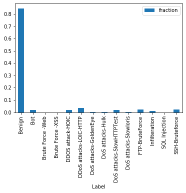

```python
size.plot.bar(x='Label', y='fraction')
```

Explore correlations between features. In can be noted that there are several groups of highly correlated features (abs(corr)>=0.9), for example:

1. 'TotLen Bwd Pkts', 'Bwd Pkt Len Max', 'Bwd Pkt Len Std', 'Bwd Header Len', and 'Pkt Len Max'
2. 'Pkt Len Std', and 'Pkt Len Max'
3. 'Flow Pkts/s', 'Flow Duration', and 'Flow IAT Max'
4. 'RST Flag Cnt' and 'ECE Flag Cnt'

These correlations, for the non-Benign labels are explored in more details further below, and since the plots show that the correlation coefficient does not represent a linear relationship, all the above features are kept.

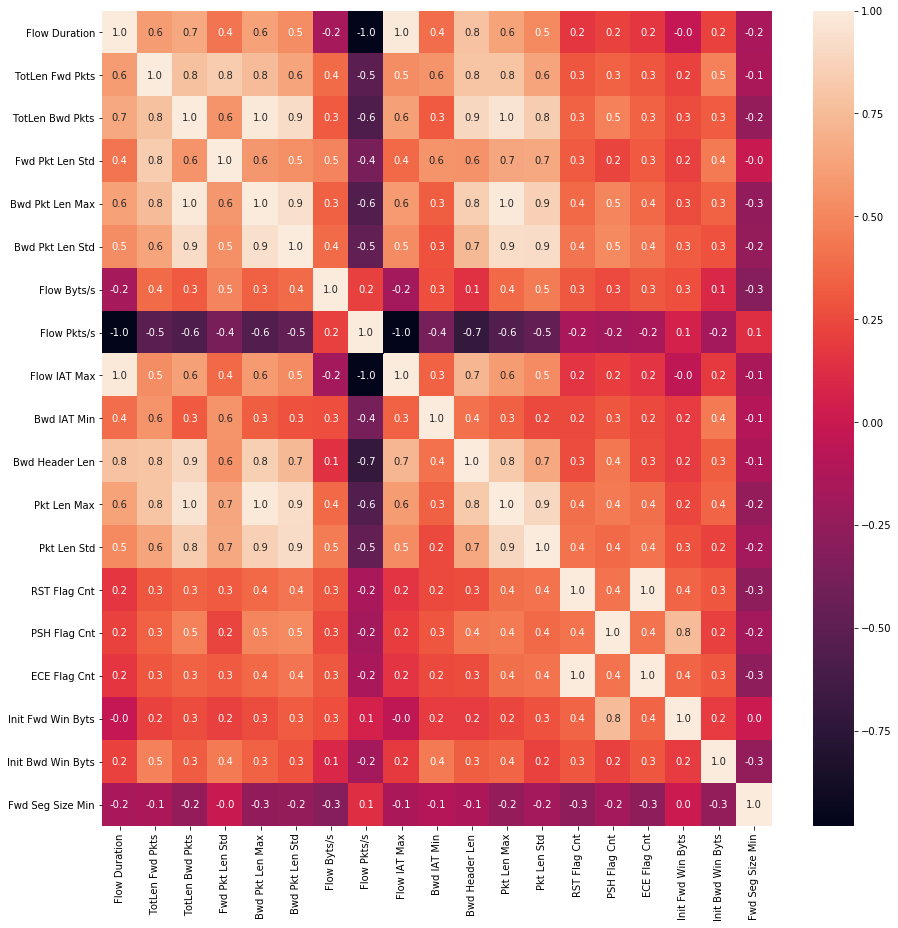

```python
df_corr = df.corr(method='spearman')
fig, ax = plt.subplots(figsize=(15, 15))
sns.heatmap(df_corr, xticklabels=df_corr.columns, yticklabels=df_corr.columns, annot=True, fmt='.1f', ax=ax)
```

```python
def plot_corr(data, x, y, xlim, ylim):
  import matplotlib.pyplot as plt
  fig, ax = plt.subplots(figsize=(15, 15))
  data.plot.scatter(x=x, y=y, ax=ax)
  ax.set_xlim(xlim)
  ax.set_ylim(ylim)
```

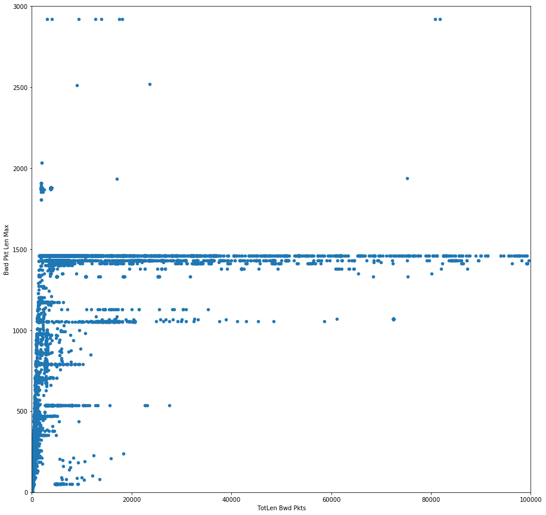

```python
plot_corr(df[df['Label'] != 'Benign'], 'TotLen Bwd Pkts', 'Bwd Pkt Len Max', xlim=(-1, 1e5), ylim=(-1, 3e3))
```

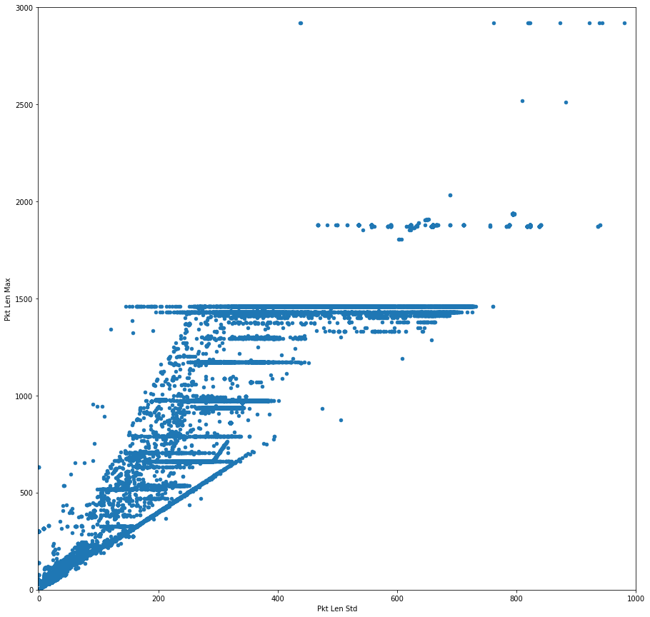

```python
plot_corr(df[df['Label'] != 'Benign'], 'Pkt Len Std', 'Pkt Len Max', xlim=(-1, 1e3), ylim=(-1, 3e3))
```

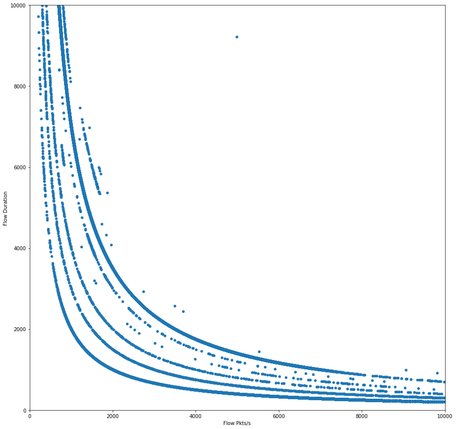

```python
plot_corr(df[df['Label'] != 'Benign'], 'Flow Pkts/s', 'Flow Duration', xlim=(-1, 1e4), ylim=(-1, 1e4))
```

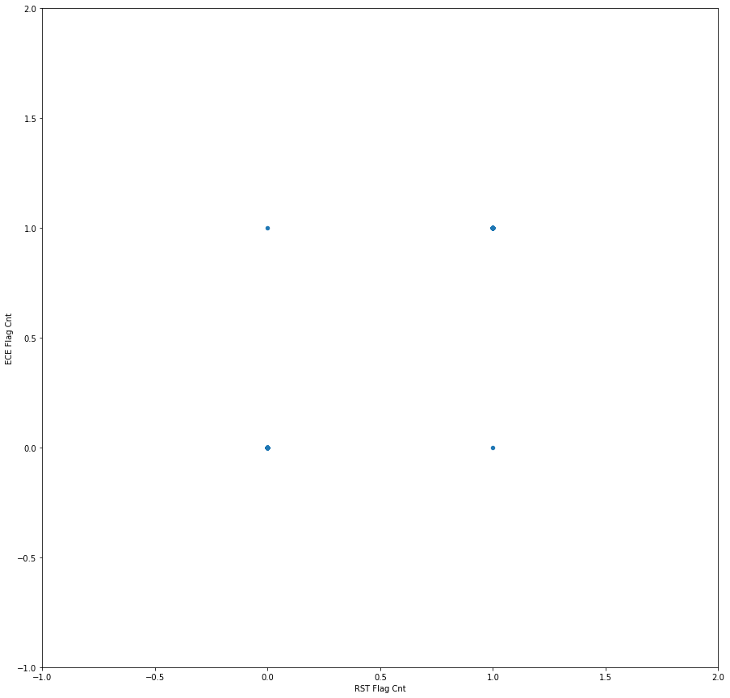

```python
plot_corr(df[df['Label'] != 'Benign'], 'RST Flag Cnt', 'ECE Flag Cnt', xlim=(-1, 2), ylim=(-1, 2))
```

Save the clean dataset archive

```python
dataset_clean_file = f'{dataset_name_clean}.zip'
```

```python
!rm -f $dataset_clean_file
!zip -r $dataset_clean_file $dataset_name_clean
```

```
  adding: cse-cic-ids2018-clean/ (stored 0%)
  adding: cse-cic-ids2018-clean/Friday-16-02-2018_TrafficForML_CICFlowMeter.csv (deflated 83%)
  adding: cse-cic-ids2018-clean/Wednesday-14-02-2018_TrafficForML_CICFlowMeter.csv (deflated 85%)
  adding: cse-cic-ids2018-clean/Friday-23-02-2018_TrafficForML_CICFlowMeter.csv (deflated 76%)
  adding: cse-cic-ids2018-clean/Wednesday-21-02-2018_TrafficForML_CICFlowMeter.csv (deflated 82%)
  adding: cse-cic-ids2018-clean/Thursday-15-02-2018_TrafficForML_CICFlowMeter.csv (deflated 76%)
  adding: cse-cic-ids2018-clean/Friday-02-03-2018_TrafficForML_CICFlowMeter.csv (deflated 79%)
  adding: cse-cic-ids2018-clean/Wednesday-28-02-2018_TrafficForML_CICFlowMeter.csv (deflated 77%)
  adding: cse-cic-ids2018-clean/Thursday-01-03-2018_TrafficForML_CICFlowMeter.csv (deflated 79%)
  adding: cse-cic-ids2018-clean/Thuesday-20-02-2018_TrafficForML_CICFlowMeter.csv (deflated 77%)
  adding: cse-cic-ids2018-clean/Thursday-22-02-2018_TrafficForML_CICFlowMeter.csv (deflated 76%)
```

```python
! /bin/cp -f $dataset_clean_file $dataset_path
```

```python
!jupyter nbconvert --to html '1-data-preprocessing.ipynb'
```

```
[NbConvertApp] Converting notebook 1-data-preprocessing.ipynb to html
[NbConvertApp] Writing 2413497 bytes to 1-data-preprocessing.html
```